# L'âge moyen des sénateurs français

Mon, 11 Jan 2016

[France](http://flothesof.github.io/tag/france.html) [Démocratie](http://flothesof.github.io/tag/democratie.html)

Cette semaine, après avoir travaillé sur [l'âge moyen des députés français](http://flothesof.github.io/age-moyen-deputes-francais.html), je vous propose de nous intéresser à celui des sénateurs.

Premier constat : la tâche ne va pas être aussi facile que dans le cas des députés. En effet, je n'ai pas réussi à trouver une base de données avec les dates de naissance des sénateurs ou de fichier PDF comme dans le cas des députés avec toutes les données d'un coup. Il va donc falloir travailler un peu plus afin d'extraire les données du [site web du sénat et son index alphabétique](http://www.senat.fr/senateurs/senatl.html).

Afin de faire ceci, nous allons utiliser les outils Python classique pour ce genre de tâche : `requests` et `beautiful soup`.

# Comment extraire la date de naissance d'un sénateur de sa notice bibliographique ?

Tout part de la notice bibliographique du sénateur. Par exemple, celle de [Michel Berson, sénateur de l'Essonne](http://www.senat.fr/senateur/berson_michel11068s.html).

On peut télécherger le contenu de cette page à l'aide du code suivant :

```python
import requests
```

```python
r = requests.get("http://www.senat.fr/senateur/berson_michel11068s.html")
r
```

```
<Response [200]>
```

La réponse 200 signifie que le téléchargement de la page s'est bien passé.

Pour extraire la date de naissance, il faut regarder le code HTML de la page et utiliser `beautiful soup`. On construit notre soupe :

```python
from bs4 import BeautifulSoup
soup = BeautifulSoup(r.text, 'html.parser')
```

La date de naissance se trouve dans un tag 'dd' lui-même contenu dans un tag 'dl'. On peut trouver ces éléments ainsi :

```python
items = soup.find('dl').find_all('dd')
items
```

```
[<dd>
 <a class="link-color-01" href="mailto:m.berson@senat.fr">m.berson@senat.fr</a>
 </dd>, <dd>
 <ul class="list-contact-01">
 <li><a href="http://www.michelberson.fr" target="_blank"><img alt="http://www.michelberson.fr" src="/fileadmin/templates/images/data/picto_contact_blog.png"/></a></li>
 <li><a href="http://www.facebook.com/michel.berson" target="_blank"><img alt="Profil Facebook" src="/fileadmin/templates/images/data/picto_contact_facebook.png"/></a></li>
 </ul>
 <ul class="list-contact-01">
 <li><a href="http://twitter.com/michel_berson" target="_blank"><img alt="Compte Twitter" src="/fileadmin/templates/images/data/picto_contact_twitter.png"/></a></li>
 </ul>
 </dd>, <dd>Né le 21 avril 1945</dd>, <dd>Cadre dans le secteur bancaire</dd>, <dd><img alt="Place dans l'hémicycle" src="/fileadmin/templates/images/senateurs/hemicycle/place-hemicycle_311.jpg" width="170">
 </img></dd>, <dd><a href="/senateurs/sencir.html#c265"><img alt="Circonscription" src="/fileadmin/templates/images/senateurs/dpt/circonscription_91.jpg"/></a>
 <div class="link link-type-02">
 <a href="/senateurs/sencir.html#c265">Tous les Sénateurs de la
 circonscription</a>
 </div>
 </dd>]
```

```python
[item.text for item in items if item.text.startswith('Né')]
```

```
['Né le 21 avril 1945']
```

On peut, sur le même principe, également écrire une fonction qui extrait le nom du sénateur de la page :

```python
soup.find('h1','title-01').text
```

```
'M. Michel Berson'
```

Maintenant que nous savons faire ça, nous pouvons écrire un fonction qui extrait la date de naissance de l'url de la page d'un sénateur, de même que son nom :

```python
def url2data(url):
    """Télécharge la page de l'url et extrait la date de naissance du sénateur."""
    r = requests.get(url)
    if r.ok:
        soup = BeautifulSoup(r.text, 'html.parser')
        birthdate = [item.text for item in soup.find('dl').find_all('dd') if item.text.startswith('Né')][0]
        name = soup.find('h1','title-01').text
        return (name, birthdate)
    else:
        raise("Something went wrong with the web request")
```

On peut tester la fonction :

```python
url2data("http://www.senat.fr/senateur/berson_michel11068s.html")
```

```
('M. Michel Berson', 'Né le 21 avril 1945')
```

Pour avoir toutes les dates de naissances, il nous faut maintenant appliquer cette procédure à toutes les urls que l'on trouve sur l'index alphabétique du sénat.

# Répéter l'opération d'extraction pour chaque sénateur

A partir de la page d'index biographique, nous pouvons, de la même manière que précédemment, extraire les liens vers les différentes pages de sénateurs :

```python
r = requests.get("http://www.senat.fr/senateurs/senatl.html")
r
```

```
<Response [200]>
```

On fait une petite sousoupe :

```python
soup = BeautifulSoup(r.text, 'html.parser')
```

Et maintenant on cherche des liens qui sont dans des balises du type ul li a. Tant qu'à faire, on ne garde que ceux qui pointen vers une page de sénateur :

```python
urls = [link.get('href') for link in soup.select('ul li a') if link.get('href').startswith('/senateur/')]
```

```python
len(urls)
```

```
348
```

Nous dénombrons bien 348 sénateurs. Passons à l'extraction des dates de naissance.

```python
birthdates = {}
for url in urls:
    name, bd = url2data("http://www.senat.fr" + url)
    birthdates[name] = bd
```

Regardons le résultat :

```python
birthdates
```

```
{'M. Abdourahamane Soilihi': 'Né le 4 octobre 1959',
 'M. Alain Anziani': 'Né le 30 mai 1951',
 'M. Alain Bertrand': 'Né le 23 février 1951',
 'M. Alain Chatillon': 'Né le 15 mars 1943',
 'M. Alain Dufaut': 'Né le 2 janvier 1944',
 'M. Alain Duran': 'Né le 2 janvier 1958',
 'M. Alain Fouché': 'Né le 4 décembre 1942',
 'M. Alain Gournac': 'Né le 13 septembre 1943',
 'M. Alain Houpert': 'Né le 13 août 1957',
 'M. Alain Joyandet': 'Né le 15 janvier 1954',
 'M. Alain Marc': 'Né le 29 janvier 1957',
 'M. Alain Milon': 'Né le 16 septembre 1947',
 'M. Alain Néri': 'Né le 1er mai 1942',
 'M. Alain Richard': 'Né le 29 août 1945',
 'M. Alain Vasselle': 'Né le 27 juin 1947',
 'M. Albéric de Montgolfier': 'Né le 6 juillet 1964',
 'M. Alex Türk': 'Né le 25 janvier 1950',
 'M. André Gattolin': 'Né le 24 juin 1960',
 'M. André Reichardt': 'Né le 5 décembre 1949',
 'M. André Trillard': 'Né le 24 octobre 1947',
 'M. Antoine Karam': 'Né le 21 février 1950',
 'M. Antoine Lefèvre': 'Né le 18 février 1966',
 'M. Benoît Huré': 'Né le 5 juin 1953',
 'M. Bernard Cazeau': 'Né le 27 avril 1939',
 'M. Bernard Delcros': 'Né le 12 février 1953',
 'M. Bernard Fournier': 'Né le 13 septembre 1946',
 'M. Bernard Lalande': 'Né le 6 avril 1954',
 'M. Bernard Saugey': 'Né le 3 mars 1943',
 'M. Bruno Gilles': 'Né le 26 décembre 1960',
 'M. Bruno Retailleau': 'Né le 20 novembre 1960',
 'M. Bruno Sido': 'Né le 19 février 1951',
 'M. Charles Guené': 'Né le 6 avril 1952',
 'M. Charles Revet': 'Né le 9 novembre 1937',
 'M. Christian Cambon': 'Né le 8 mars 1948',
 'M. Christian Favier': 'Né le 20 février 1951',
 'M. Christian Manable': 'Né le 19 juin 1948',
 'M. Christian Namy': 'Né le 19 octobre 1938',
 'M. Christophe Béchu': 'Né le 11 juin 1974',
 'M. Christophe-André Frassa': 'Né le 4 février 1968',
 'M. Claude Bérit-Débat': 'Né le 19 février 1946',
```

[output cut: 293 more lines]

```
 'Mme Patricia Morhet-Richaud': 'Née le 28 juillet 1961',
 'Mme Patricia Schillinger': 'Née le 18 janvier 1963',
 'Mme Samia Ghali': 'Née le 10 juin 1968',
 'Mme Sophie Joissains': 'Née le 25 octobre 1969',
 'Mme Sophie Primas': 'Née le 6 juin 1962',
 'Mme Stéphanie Riocreux': 'Née le 20 mai 1966',
 'Mme Sylvie Goy-Chavent': 'Née le 23 mai 1963',
 'Mme Sylvie Robert': 'Née le 28 août 1963',
 'Mme Valérie Létard': 'Née le 13 octobre 1962',
 'Mme Vivette Lopez': 'Née le 27 décembre 1954',
 'Mme Éliane Assassi': 'Née le 2 octobre 1958',
 'Mme Éliane Giraud': 'Née le 12 mars 1952',
 'Mme Élisabeth Doineau': 'Née le 7 avril 1961',
 'Mme Élisabeth Lamure': 'Née le 20 novembre 1947',
 'Mme Évelyne Didier': 'Née le 14 mars 1948'}
```

On peut facilement construire une dataframe pandas avec ces données :

```python
import pandas as pd
```

```python
df = pd.DataFrame(data=[(key, birthdates[key]) for key in birthdates],
             columns=('Nom', 'Date de naissance'))
df.head()
```

|  | Nom | Date de naissance |
| --- | --- | --- |
| 0 | Mme Catherine Génisson | Née le 22 avril 1949 |
| 1 | Mme Anne Chain-Larché | Née le 11 avril 1958 |
| 2 | M. Georges Patient | Né le 1er avril 1949 |
| 3 | Mme Corinne Bouchoux | Née le 5 janvier 1964 |
| 4 | M. Martial Bourquin | Né le 23 juillet 1952 |

On peut, comme dans mon billet précédent, calculer des dates de naissance numériques à l'aide de ces données :

```python
def convert2date(date_str):
    d = {'janvier': 1, 'février': 2, 'mars': 3, 'avril': 4,
         'mai': 5, 'juin': 6, 'juillet': 7, 'août': 8,
         'septembre': 9, 'octobre': 10, 'novembre': 11, 'décembre':12}
    splits = date_str.split(' ')[2:]

    if splits[0].startswith('1er'):
        splits.pop(0)
        splits.insert(0, '1')

    return pd.Timestamp(splits[2] + '/' + str(d[splits[1]]) + '/' + splits[0])
```

```python
df['Date de naissance2'] = df['Date de naissance'].map(convert2date)
```

```python
df.head()
```

|  | Nom | Date de naissance | Date de naissance2 |
| --- | --- | --- | --- |
| 0 | Mme Catherine Génisson | Née le 22 avril 1949 | 1949-04-22 |
| 1 | Mme Anne Chain-Larché | Née le 11 avril 1958 | 1958-04-11 |
| 2 | M. Georges Patient | Né le 1er avril 1949 | 1949-04-01 |
| 3 | Mme Corinne Bouchoux | Née le 5 janvier 1964 | 1964-01-05 |
| 4 | M. Martial Bourquin | Né le 23 juillet 1952 | 1952-07-23 |

Enfin, on peut calculer l'âge de chaque sénateur :

```python
import datetime
```

```python
df['Âge'] = pd.Timestamp(datetime.date.today()) - df['Date de naissance2']
df['Âge (années)'] = [x.days / 365.25 for x in df['Âge']]
```

```python
df.head()
```

|  | Nom | Date de naissance | Date de naissance2 | Âge | Âge (années) |
| --- | --- | --- | --- | --- | --- |
| 0 | Mme Catherine Génisson | Née le 22 avril 1949 | 1949-04-22 | 24379 days | 66.746064 |
| 1 | Mme Anne Chain-Larché | Née le 11 avril 1958 | 1958-04-11 | 21103 days | 57.776865 |
| 2 | M. Georges Patient | Né le 1er avril 1949 | 1949-04-01 | 24400 days | 66.803559 |
| 3 | Mme Corinne Bouchoux | Née le 5 janvier 1964 | 1964-01-05 | 19008 days | 52.041068 |
| 4 | M. Martial Bourquin | Né le 23 juillet 1952 | 1952-07-23 | 23191 days | 63.493498 |

# Analyse des données recueillies

On peut maintenant tracer de jolis histogrammes :

```python
%matplotlib inline
import matplotlib.pyplot as plt
plt.style.use('ggplot')
```

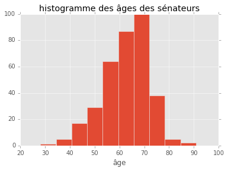

```python
df['Âge (années)'].hist()
plt.xlabel('âge')
plt.title('histogramme des âges des sénateurs')
```

Afin de comparer ces âges à la population française, nous réutilisons le code de mon post précédent :

```python
df_pop = pd.read_excel('http://www.insee.fr/fr/ppp/bases-de-donnees/donnees-detaillees/bilan-demo/fichiers-xls/pop-1janvier-fm.xls',
                      skiprows=7,
                      header=1,
                      skipfooter=3)
```

```python
decimation_factor = 1000
french_pop_ages = []
for ind, value in enumerate(df_pop['Ensemble']):
    french_pop_ages += [ind for _ in range(int(value / decimation_factor))]
```

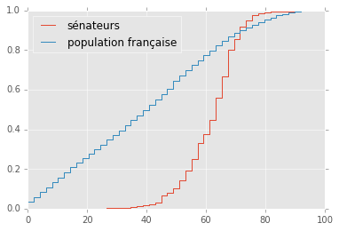

```python
import numpy as np
import statsmodels.api as sm # recommended import according to the docs

age_grid = np.linspace(0, 100)
ecdf_mp = sm.distributions.ECDF(df['Âge (années)'].values)
ecdf_french_pop = sm.distributions.ECDF(french_pop_ages)
y_mp = ecdf_mp(age_grid)
y_french_pop = ecdf_french_pop(age_grid)
plt.step(age_grid, y_mp, label='sénateurs')
plt.step(age_grid, y_french_pop, label='population française')
plt.legend(loc='upper left')
```

Finalement, on peut passer à la comparaison des statistiques par quartiles :

```python
df['Âge (années)'].describe()
```

```
count    348.000000
mean      62.791947
std        9.050571
min       28.134155
25%       57.147844
50%       63.954825
75%       68.805613
max       90.877481
Name: Âge (années), dtype: float64
```

```python
pd.Series(french_pop_ages).describe()
```

```
count    64461.000000
mean        40.705931
std         24.080480
min          0.000000
25%         20.000000
50%         41.000000
75%         60.000000
max        105.000000
dtype: float64
```

Finalement, on peut produire le tableau récapitulatif suivant :

[output not shown]

# Conclusions

Cette nouvelle analyse consolide l'idée selon laquelle les français sont représentés par des élus dans une tranche d'âge bien éloignée d'une répartition comparable à la population française.

Evidemment, il est difficile de tirer des conclusions générales à partir de ce chiffre, mais il est frappant à quel point les sénateurs sont vieux par rapport disons, l'âge de la retraite. D'une certaine manière, la moitié des sénateurs ont plus que l'âge de la retraite.

This article has been tagged with the following terms:

[France](http://flothesof.github.io/tag/france.html) [Démocratie](http://flothesof.github.io/tag/democratie.html)

[figure not shown]